# Winter (2013), Tutorial 2: el modelo lineal mixto

- Mostrar todo el código
- Ocultar todo el código
- Ver el código fuente

Reproducción paso a paso

Autor/a

Filip Andras — CIMCYC, Universidad de Granada

Fecha de publicación

12 noviembre 2026

Resumen

El modelo lineal mixto con los datos de cortesía de Winter: interceptos variables por hablante y por escenario, el género como efecto fijo, el test de razón de verosimilitudes para la actitud y un modelo con pendientes variables que resulta degenerado. Al final, los supuestos y cómo redactar el análisis.

Este documento sigue el segundo tutorial de Winter (2013), *Linear models and linear mixed effects models in R with linguistic applications* (arXiv:1308.5499). El primer tutorial, el modelo lineal y sus supuestos, está en un documento aparte. Los conceptos (efectos fijos y aleatorios, interceptos y pendientes variables) están en la introducción conceptual.

# El modelo lineal mixto

> El ejemplo de Winter: el tono de voz y la cortesía (Winter y Grawunder, 2012). Seis hablantes, tres mujeres y tres hombres, respondieron en registro cortés y en registro informal en siete escenarios distintos, como pedir un favor o disculparse por llegar tarde. De cada respuesta se midió el tono medio de voz, en Hz. La pregunta: ¿baja el tono al hablar con cortesía?

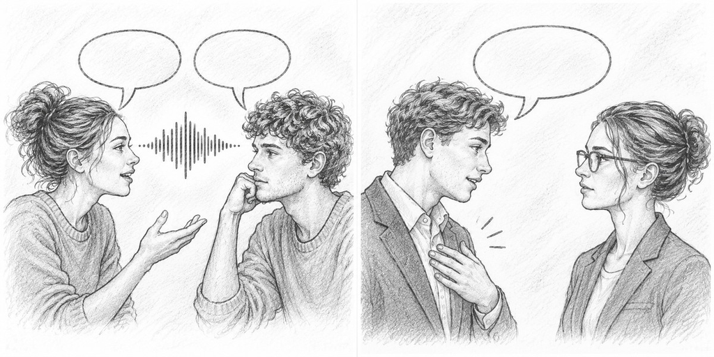

## Conocer los datos

```r
# En el archivo, el tono de voz (Hz) se llama frequency: lo renombramos a
# pitch, como en el tutorial 1
politeness <- read_csv(
  file = here("exercises", "data", "raw_data", "politeness_data.csv"),
  show_col_types = FALSE
) |>
  rename(pitch = frequency)
print(politeness)
```

```
# A tibble: 84 × 5
   subject gender scenario attitude pitch
   <chr>   <chr>     <dbl> <chr>    <dbl>
 1 F1      F             1 pol      213.3
 2 F1      F             1 inf      204.5
 3 F1      F             2 pol      285.1
 4 F1      F             2 inf      259.7
 5 F1      F             3 pol      203.9
 6 F1      F             3 inf      286.9
 7 F1      F             4 pol      250.8
 8 F1      F             4 inf      276.8
 9 F1      F             5 pol      231.9
10 F1      F             5 inf      252.4
# ℹ 74 more rows
```

Las primeras filas son de la participante F1: sus respuestas cortés y informal en los escenarios 1 a 5. Cada fila es una respuesta, con el hablante, su género, el escenario, la actitud y el tono en Hz.

```r
xtabs(formula = ~ subject + scenario, data = politeness)
```

```
       scenario
subject 1 2 3 4 5 6 7
     F1 2 2 2 2 2 2 2
     F2 2 2 2 2 2 2 2
     F3 2 2 2 2 2 2 2
     M3 2 2 2 2 2 2 2
     M4 2 2 2 2 2 2 2
     M7 2 2 2 2 2 2 2
```

El cruce de hablante y escenario: cada hablante pasa por los siete escenarios y cada escenario por los seis hablantes. Cada celda tiene dos respuestas, una cortés y una informal. Hablante y escenario están **cruzados**, no anidados.

Tono por actitud y género. Lo cortés es más grave en los dos géneros; la diferencia entre géneros es mucho mayor que la de actitud.

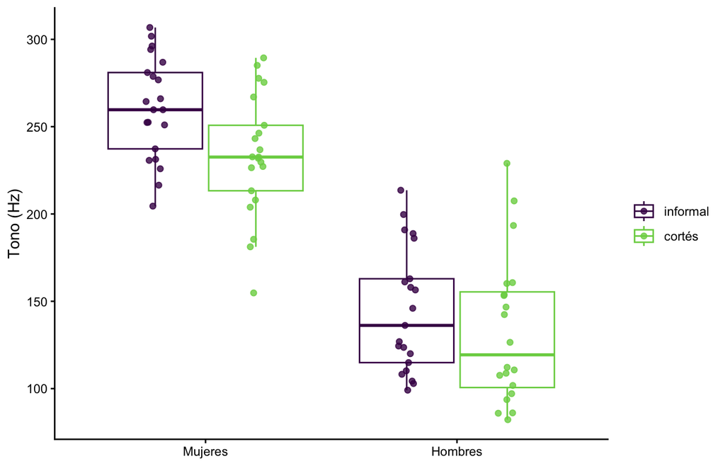

## Interceptos variables por hablante y por escenario

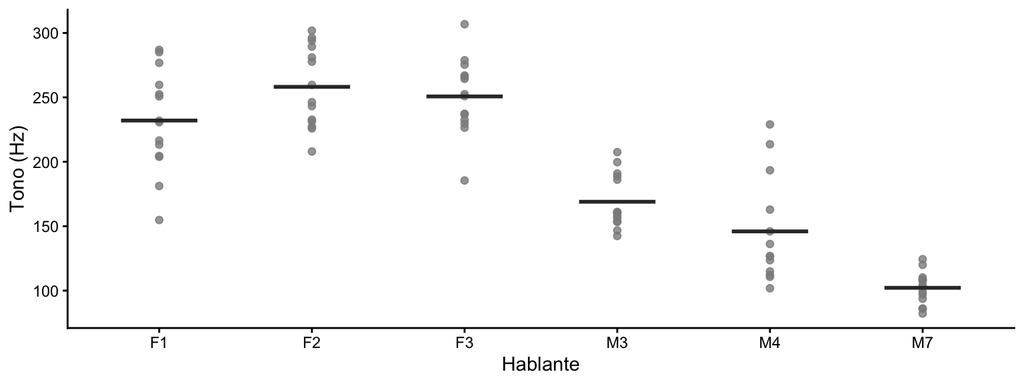

Cada punto es una respuesta y la raya, la media de cada hablante. Los hombres son más graves que las mujeres, y dentro de cada sexo cada hablante tiene su propio nivel.

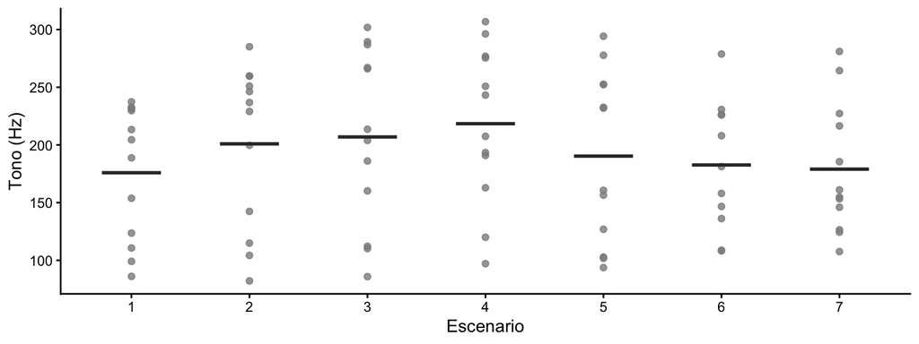

Lo mismo por escenario. La variación entre escenarios es menor que entre hablantes, pero existe.

`pitch ~ attitude + (1|subject) + (1|scenario)`

`(1 | subject)`: cada hablante tiene su propio tono de base. `(1 | scenario)`: cada escenario tiene su propio tono de base.

```r
politeness_model <- lmer(
  formula = pitch ~ attitude + (1 | subject) + (1 | scenario),
  data = politeness
)
summary(politeness_model)
```

```
Linear mixed model fit by REML ['lmerMod']
Formula: pitch ~ attitude + (1 | subject) + (1 | scenario)
   Data: politeness

REML criterion at convergence: 793.5

Scaled residuals:
    Min      1Q  Median      3Q     Max
-2.2006 -0.5817 -0.0639  0.5625  3.4385

Random effects:
 Groups   Name        Variance Std.Dev.
 scenario (Intercept)  219     14.80
 subject  (Intercept) 4015     63.36
 Residual              646     25.42
Number of obs: 83, groups:  scenario, 7; subject, 6

Fixed effects:
            Estimate Std. Error t value
(Intercept)  202.588     26.754   7.572
attitudepol  -19.695      5.585  -3.527

Correlation of Fixed Effects:
            (Intr)
attitudepol -0.103
```

Qué mirar en la salida, en este orden:

- **Random effects:** la desviación típica entre hablantes (grande: hay hombres y mujeres) y entre escenarios (pequeña), y la residual, lo que queda sin explicar. Son las tres fuentes de variación del modelo.
- **Fixed effects:** `(Intercept)` es el tono medio en la condición de referencia, `inf` por orden alfabético. `attitudepol` es cuánto baja el tono al ser cortés, unos 20 Hz. Al lado, su error típico y el valor t, sin p-valor: `lme4` no lo da.

El intercepto, 202.6 Hz, no es el tono de nadie: está a medio camino entre hombres y mujeres, porque el modelo no sabe que hay dos sexos. La analogía de la granja: con doce gallinas y doce vacas, la media de patas por animal es tres.

## Añadir el género como efecto fijo

El género explica buena parte de la variación entre hablantes. Al meterlo como efecto fijo, la desviación típica del intercepto por hablante baja mucho: esa varianza se “mueve” del efecto aleatorio al fijo. Y el intercepto pasa a ser el tono de las mujeres en la condición informal.

`pitch ~ attitude + gender + (1|subject) + (1|scenario)`

```r
politeness_model_gender <- lmer(
  formula = pitch ~ attitude + gender +
    (1 | subject) + (1 | scenario),
  data = politeness
)
summary(politeness_model_gender)
```

```
Linear mixed model fit by REML ['lmerMod']
Formula: pitch ~ attitude + gender + (1 | subject) + (1 | scenario)
   Data: politeness

REML criterion at convergence: 775.5

Scaled residuals:
    Min      1Q  Median      3Q     Max
-2.2591 -0.6236 -0.0772  0.5388  3.4795

Random effects:
 Groups   Name        Variance Std.Dev.
 scenario (Intercept) 219.5    14.81
 subject  (Intercept) 615.6    24.81
 Residual             645.9    25.41
Number of obs: 83, groups:  scenario, 7; subject, 6

Fixed effects:
            Estimate Std. Error t value
(Intercept)  256.846     16.116  15.938
attitudepol  -19.721      5.584  -3.532
genderM     -108.516     21.013  -5.164

Correlation of Fixed Effects:
            (Intr) atttdp
attitudepol -0.173
genderM     -0.652  0.004
```

**La salida, en la ecuación.**

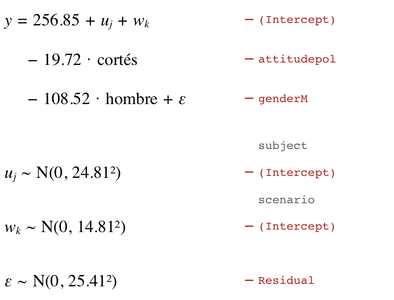

$j$ es el hablante y $k$ el escenario: $u_j$ es la desviación de cada hablante y $w_k$, la de cada escenario. cortés = 1 en las respuestas corteses y hombre = 1 en los hablantes hombres.

La desviación típica por hablante en los dos modelos:

```r
VarCorr(politeness_model)
```

```
 Groups   Name        Std.Dev.
 scenario (Intercept) 14.798
 subject  (Intercept) 63.360
 Residual             25.417
```

```r
VarCorr(politeness_model_gender)
```

```
 Groups   Name        Std.Dev.
 scenario (Intercept) 14.814
 subject  (Intercept) 24.811
 Residual             25.414
```

Las dos variables a la vez: el tono que predice el modelo para cada género y cada actitud, con su intervalo de confianza del 95 %.

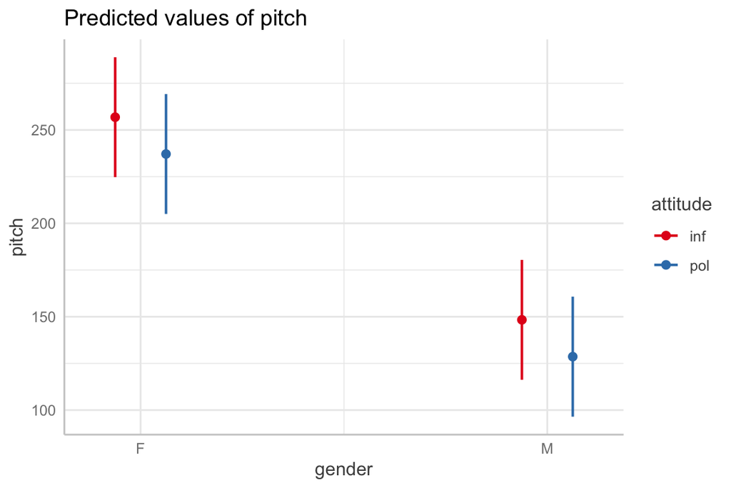

```r
# Predicciones del modelo para cada combinacion de genero y actitud
gender_predictions <- ggeffects::ggpredict(
  model = politeness_model_gender,
  terms = c("gender", "attitude")
)
plot(gender_predictions)
```

## El p-valor de la actitud: test de razón de verosimilitudes (*likelihood ratio test*)

Se compara el modelo con actitud contra el mismo modelo sin ella. Los dos se ajustan con `REML = FALSE`, máxima verosimilitud completa, que es lo que exige la comparación por verosimilitud. `anova()` hace el test: chi cuadrado con 1 grado de libertad, la diferencia en número de parámetros.

Modelo nulo:

`pitch ~ gender + (1|subject) + (1|scenario)`

Modelo completo:

`pitch ~ attitude + gender + (1|subject) + (1|scenario)`

```r
politeness_null_ml <- lmer(
  formula = pitch ~ gender + (1 | subject) + (1 | scenario),
  data = politeness, REML = FALSE
)
politeness_model_ml <- lmer(
  formula = pitch ~ attitude + gender +
    (1 | subject) + (1 | scenario),
  data = politeness, REML = FALSE
)
anova(politeness_null_ml, politeness_model_ml)
```

```
Data: politeness
Models:
politeness_null_ml: pitch ~ gender + (1 | subject) + (1 | scenario)
politeness_model_ml: pitch ~ attitude + gender + (1 | subject) + (1 | scenario)
                    npar    AIC    BIC  logLik -2*log(L)  Chisq Df Pr(>Chisq)
politeness_null_ml     5 816.72 828.81 -403.36    806.72
politeness_model_ml    6 807.10 821.61 -397.55    795.10 11.618  1  0.0006532

politeness_null_ml
politeness_model_ml ***
---
Signif. codes:  0 '***' 0.001 '**' 0.01 '*' 0.05 '.' 0.1 ' ' 1
```

**NotaPara comparar dos modelos con anova()**

- Los dos modelos se ajustan con `REML = FALSE`.
- La estructura aleatoria tiene que ser idéntica en los dos: lo único que cambia es el efecto fijo que se contrasta.

Cómo lo reporta Winter: “la cortesía afectó al tono (chi cuadrado(1) = 11.62, p = 0.00065), bajándolo unos 19.7 Hz ± 5.6 (errores típicos)”. El tamaño del efecto sale de los coeficientes del modelo completo:

```r
coef(summary(politeness_model_ml))
```

```
              Estimate Std. Error   t value
(Intercept)  256.84675  13.826771 18.576048
attitudepol  -19.72207   5.547102 -3.555384
genderM     -108.51731  17.571393 -6.175794
```

El género se queda en los dos modelos: es la variable de control, y la actitud es la que se contrasta. Una interacción se contrasta igual: `attitude * gender` frente a `attitude + gender`.

## Pendientes variables

Es poco realista que la cortesía afecte igual a todo el mundo y en todos los escenarios. `(1 + attitude | subject)` deja que cada hablante tenga su propio intercepto y su propia pendiente de actitud; igual para el escenario. Winter lo llama “super crucial” y dice que el modelo debe incluir las pendientes variables de todo efecto fijo que importe para la interpretación.

`pitch ~ attitude + gender + (1 + attitude|subject) + (1 + attitude|scenario)`

```r
politeness_model_slopes <- lmer(
  formula = pitch ~ attitude + gender +
    (1 + attitude | subject) + (1 + attitude | scenario),
  data = politeness, REML = FALSE
)
```

```
boundary (singular) fit: see help('isSingular')
```

```r
summary(politeness_model_slopes)
```

```
Linear mixed model fit by maximum likelihood  ['lmerMod']
Formula:
pitch ~ attitude + gender + (1 + attitude | subject) + (1 + attitude |
    scenario)
   Data: politeness

      AIC       BIC    logLik -2*log(L)  df.resid
    814.9     839.1    -397.4     794.9        73

Scaled residuals:
    Min      1Q  Median      3Q     Max
-2.1946 -0.6690 -0.0789  0.5256  3.4251

Random effects:
 Groups   Name        Variance Std.Dev. Corr
 scenario (Intercept) 182.083  13.494
          attitudepol  31.244   5.590   0.22
 subject  (Intercept) 392.344  19.808
          attitudepol   1.714   1.309   1.00
 Residual             627.890  25.058
Number of obs: 83, groups:  scenario, 7; subject, 6

Fixed effects:
            Estimate Std. Error t value
(Intercept)  257.991     13.528  19.071
attitudepol  -19.747      5.922  -3.335
genderM     -110.806     17.510  -6.328

Correlation of Fixed Effects:
            (Intr) atttdp
attitudepol -0.105
genderM     -0.647  0.003
optimizer (nloptwrap) convergence code: 0 (OK)
boundary (singular) fit: see help('isSingular')
```

El aviso `boundary (singular) fit` dice que el modelo es **degenerado**: alguna estimación de la parte aleatoria ha quedado en el límite de lo posible. En la salida se ve en *Random effects*: la correlación entre el intercepto y la pendiente por hablante es 1.00, y la desviación típica de esa pendiente, 1.31 Hz, es casi cero. Con 6 hablantes, los datos no dan para estimar una pendiente distinta para cada uno.

```r
isSingular(politeness_model_slopes)
```

```
[1] TRUE
```

El Día 2 usaremos `rePCA()` para simplificar la estructura aleatoria.

## Supuestos del modelo mixto

Los mismos supuestos que el modelo lineal, comprobados igual. `check_model()` los enseña todos de una vez y, para un modelo mixto, añade un panel con la normalidad de los efectos aleatorios: los interceptos y pendientes por hablante y por escenario también se asumen normales.

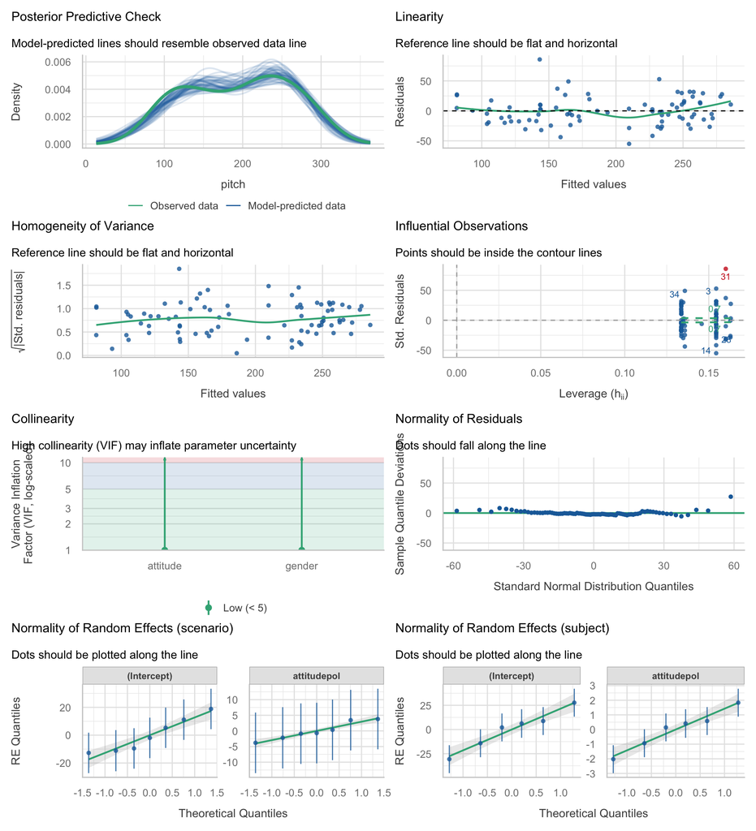

```r
performance::check_model(politeness_model_slopes)
```

La independencia merece una palabra aparte. Pasamos al modelo mixto justamente para resolverla, pero un modelo mixto también puede violarla si le falta un efecto fijo o aleatorio importante. Un modelo sin `(1 | subject)` no sabría que hay varias respuestas por hablante, y volveríamos a la pseudorreplicación del Tutorial 1.

## Cómo redactarlo

El texto tiene que permitir reproducir el análisis: todos los efectos fijos y aleatorios, si hay interceptos o pendientes variables, cómo se obtuvieron los p-valores, que se comprobaron los supuestos, y las versiones de R y de `lme4`. Para el análisis de este tutorial, así se redactaría en inglés:

> We analysed voice pitch (Hz) with a linear mixed-effects model in R (version 4.6.1; R Core Team, 2026) using the lme4 package (version 2.0.6; Bates et al., 2015). The data comprised 83 responses from 6 speakers (three female, three male) across 7 scenarios. Politeness (informal vs. polite) and gender were entered as fixed effects without an interaction, with treatment coding and informal speech and female speakers as reference levels. A model that also included by-speaker and by-scenario random slopes for politeness yielded a singular fit, so the final model included random intercepts for speakers and scenarios only. Visual inspection of residual plots revealed no obvious departures from homoscedasticity or normality. The effect of politeness was tested with a likelihood-ratio test between models fitted by maximum likelihood, comparing the full model with a model without politeness and with the same random-effects structure; the estimate and its standard error come from the model fitted by restricted maximum likelihood (REML). Polite speech lowered pitch by 19.7 Hz (*SE* = 5.6), χ²(1) = 11.62, *p* < .001.

Y citar a quienes hicieron las herramientas:

```r
citation("lme4")
```

```
  Douglas Bates, Martin Maechler, Ben Bolker, Steve Walker (2015).
  Fitting Linear Mixed-Effects Models Using lme4. Journal of
  Statistical Software, 67(1), 1-48. doi:10.18637/jss.v067.i01.

A BibTeX entry for LaTeX users is

  @Article{,
    title = {Fitting Linear Mixed-Effects Models Using {lme4}},
    author = {Douglas Bates and Martin M{\"a}chler and Ben Bolker and Steve Walker},
    journal = {Journal of Statistical Software},
    year = {2015},
    volume = {67},
    number = {1},
    pages = {1--48},
    doi = {10.18637/jss.v067.i01},
  }
```

# Referencias

Bates, D., Mächler, M., Bolker, B., & Walker, S. (2015). Fitting linear mixed-effects models using lme4. *Journal of Statistical Software, 67*(1), 1–48. https://doi.org/10.18637/jss.v067.i01

Winter, B. (2013). *Linear models and linear mixed effects models in R with linguistic applications*. arXiv:1308.5499. https://arxiv.org/abs/1308.5499

Winter, B., & Grawunder, S. (2012). The phonetic profile of Korean formal and informal speech registers. *Journal of Phonetics, 40*(6), 808–815. https://doi.org/10.1016/j.wocn.2012.08.006

# Session information

**Código**